# Peer Assessment 1

by: Matt Marchand  
last updated: 11/9/2014  
===============================================================================

## Part 1

### Load & Preprocess Data

```r
    library(data.table)
    library(ggplot2)

    setwd("C:/Users/Matt/Desktop/Coursera/Reproducible Research")
    activity_data <- read.csv("activity.csv")
```

## Part 2

### What is mean total number of steps taken per day?

For this part of the assignment, you can ignore the missing values in the dataset.

```
1. Make a histogram of the total number of steps taken each day.
```

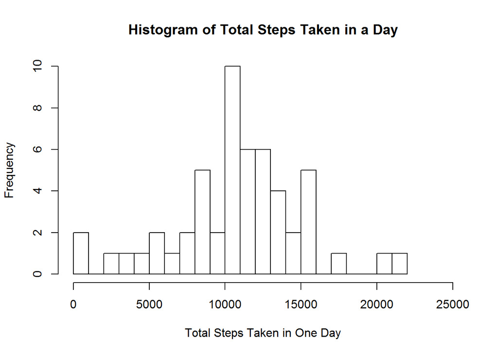

```
2. Calculate and report the mean and median total number of steps taken per day.
```

```r
    steps_for_hist <- aggregate(steps ~ date, activity_data, sum)
    hist(steps_for_hist$steps,
        main = "Histogram of Total Steps Taken in a Day",
        breaks = 25,
        xlab = "Total Steps Taken in One Day",
        ylab = "Frequency",
        xlim = c(0, 25000))
```

```r
    mean_steps <- mean(steps_for_hist$steps)
    median_steps <- median(steps_for_hist$steps)
```

The mean total steps per day is: 10766.19  
The median total steps per day is: 10765

## Part 3

### What is the average daily activity pattern?

```
1. Make a time series plot (i.e. type = "l") of the 5-minute interval
   (x-axis) and the average number of steps taken, averaged across all
   days (y-axis).
```

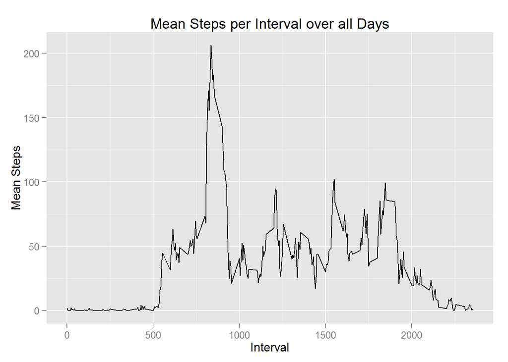

```
2. Which 5-minute interval, on average across all the days in the
   dataset, contains the maximum number of steps?
```

```r
    mean_steps_per_interval <- aggregate(steps ~ interval, activity_data, mean)

    part3plot <- ggplot(mean_steps_per_interval, aes(interval, steps, group = 1)) +
        geom_line() +
        xlab("Interval") +
        ylab("Mean Steps") +
        ggtitle("Mean Steps per Interval over all Days")
    part3plot
```

```r
    high_interval <- mean_steps_per_interval[mean_steps_per_interval$steps ==
                     max(mean_steps_per_interval$steps),]
```

The interval with the highest average steps per day is: 835

## Part 4

### Imputing missing values

```
1. Calculate and report the total number of missing values in the dataset
   (i.e. the total number of rows with NAs)
```

```r
    totalNAs <- sum(is.na(activity_data$steps) == TRUE)
```

The total NAs in the original dataset is: 2304

```
2. Devise a strategy for filling in all of the missing values in the dataset.
   The strategy does not need to be sophisticated. For example, you could use
   the mean/median for that day, or the mean for that 5-minute interval, etc.
```

```
3. Create a new dataset that is equal to the original dataset but with the
   missing data filled in.
```

```r
    activity_data_noNA <- activity_data

    replaceNAs <- function(interval, steps){
        if(is.na(steps)){
            updated_steps <- mean_steps_per_interval[mean_steps_per_interval$interval==interval, 2]
        }
        else
            updated_steps <- steps
        return(updated_steps)
    }

    activity_data_noNA$steps <- mapply(replaceNAs, activity_data_noNA$interval, activity_data_noNA$steps)
```

```
4. Make a histogram of the total number of steps taken each day and
   calculate and report the mean and median total number of steps taken
   per day. Do these values differ from the estimates from the first
   part of the assignment? What is the impact of imputing missing data
   on the estimates of the total daily number of steps?
```

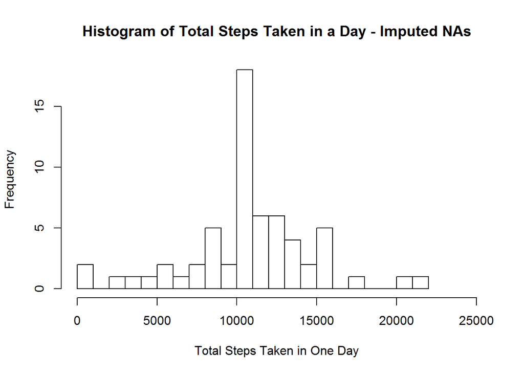

```r
    steps_for_hist_noNA <- aggregate(steps ~ date, activity_data_noNA, sum)

    hist(steps_for_hist_noNA$steps,
        main = "Histogram of Total Steps Taken in a Day - Imputed NAs",
        breaks = 25,
        xlab = "Total Steps Taken in One Day",
        ylab = "Frequency",
        xlim = c(0, 25000))
```

```r
    mean_steps_noNA <- mean(steps_for_hist_noNA$steps)
    median_steps_noNA <- median(steps_for_hist_noNA$steps)
```

The new mean total steps per day is: 10766.19  
The new median total steps per day is: 10766

The mean has not changed, which makes sense expected since we used average  
values to impute the missing data.  
The median value has increased slightly, this also makes sense since we have  
changed the total number of non-NA values in the dataset.

## Part 5

### Are there differences in activity patterns between weekdays and weekends?

```
For this part the weekdays() function may be of some help here. Use the
dataset with the filled-in missing values for this part.

1. Create a new factor variable in the dataset with two levels - "weekday"
   and "weekend" indicating whether a given date is a weekday or weekend day.
```

```r
    activity_data_noNA$daytype <- weekdays(as.Date(activity_data[,2]))

    weekdaytype <- function(day){
        if(day == "Saturday" | day == "Sunday")
            week_part <- "Weekend"
        else
            week_part <- "Weekday"
        return(week_part)
    }

    activity_data_noNA$daytype <- mapply(weekdaytype, activity_data_noNA$daytype)
```

```
2. Make a panel plot containing a time series plot (i.e. type = "l") of
   the 5-minute interval (x-axis) and the average number of steps taken,
   averaged across all weekday days or weekend days (y-axis). See the
   README file in the GitHub repository to see an example of what this
   plot should look like using simulated data.
```

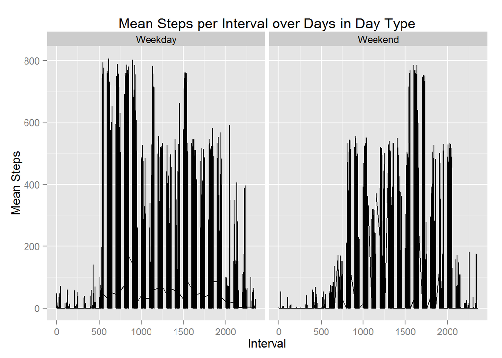

```r
    part5plot <- ggplot(activity_data_noNA, aes(interval, steps, group = 1)) +
        geom_line() +
        facet_grid(. ~ daytype) +
        xlab("Interval") +
        ylab("Mean Steps") +
        ggtitle("Mean Steps per Interval over Days in Day Type")
    part5plot
```